# Chapter 23: Model Basics

# A simple model

Next, we compute the overall distance between the predicted and actual values with the root-mean-squared deviation. We compute the distance between actual and predicted, square them, average them, and then take the square root.

Now we use **purrr** to compute the distance for all the models defined above.

Now we overlay the 10 best models on to the data.

```r
ggplot(sim1, aes(x, y)) +
  geom_point(size = 2, color = "grey30") +
  geom_abline(
    data = filter(models, rank(dist) <= 10),
    aes(intercept = a1, slope = a2, color = -dist)
  )
```

## Exercises

1. One downside of the linear model is that it is sensitive to unusual values because the distance incorporates a squared term. Fit a linear model to the simulated data below, and visualise the results. Rerun a few times to generate different simulated datasets. What do you notice about the model?

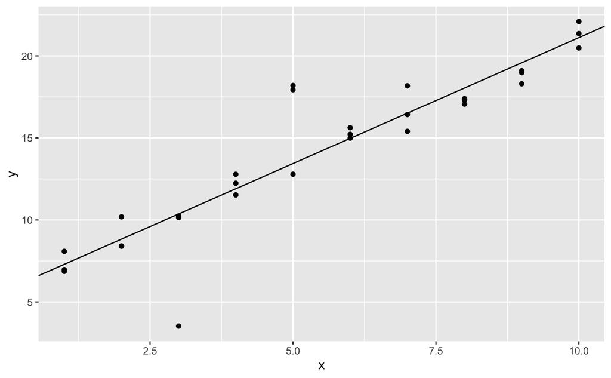

2. One way to make linear models more robust is to use a different distance measure. For example, instead of root-mean-squared distance, you could use mean-absolute distance. Use [`optim()`](https://rdrr.io/r/stats/optim.html) to fit this model to the simulated data above and compare it to the linear model.

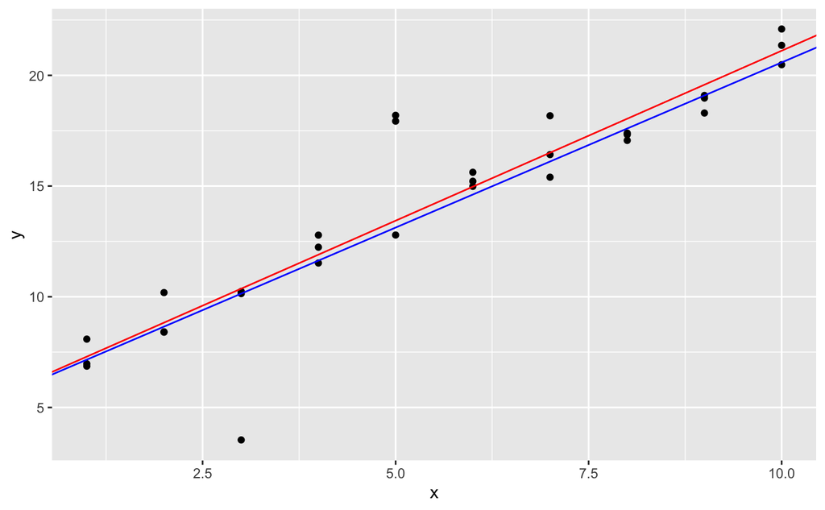

3. One challenge with performing numerical optimization is that it’s only guaranteed to find one local optimum. Whats the problem with optimizing a three parameter model like this?

```r
model1 <- function(a, data) {
  a[1] + data$x * a[2] + a[3]
}
```

# Visualizing Models

## Predictions

To visualize the predictions from a model, we start by generating an evenly spaced grid of values that covers the region where out data lies. The easiest way to do this is to use `modelr::data_grid()`.

| x |
| --- |
| 1 |
| 2 |
| 3 |
| 4 |
| 5 |
| 6 |
| 7 |
| 8 |
| 9 |
| 10 |

We add predictions from the model with `modelr::add_predictions()`:

| x | pred |
| --- | --- |
| 1 | 6.272355 |
| 2 | 8.323888 |
| 3 | 10.375421 |
| 4 | 12.426954 |
| 5 | 14.478487 |
| 6 | 16.530020 |
| 7 | 18.581553 |
| 8 | 20.633087 |
| 9 | 22.684620 |
| 10 | 24.736153 |

Now we plot the predictions:

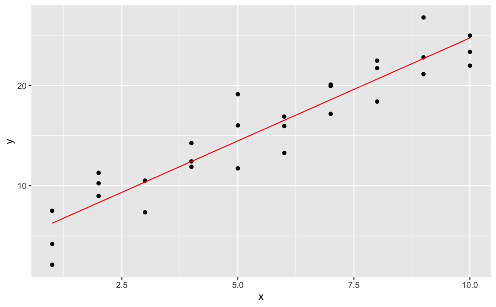

## Residuals

We add residuals to the data with `add_residuals()`.

| x | y | resid |
| --- | --- | --- |
| 1 | 4.199913 | -2.072442018 |
| 1 | 7.510634 | 1.238279125 |
| 1 | 2.125473 | -4.146882207 |
| 2 | 8.988857 | 0.664969362 |
| 2 | 10.243105 | 1.919217378 |
| 2 | 11.296823 | 2.972935148 |
| 3 | 7.356365 | -3.019056466 |
| 3 | 10.505349 | 0.129928252 |
| 3 | 10.511601 | 0.136179642 |
| 4 | 12.434589 | 0.007634878 |

[output cut: 20 more lines]

There are a number of ways to understand what the residuals tell us about the model. One way is to simply draw a frequency polygon to help us understand the spread of the residuals:

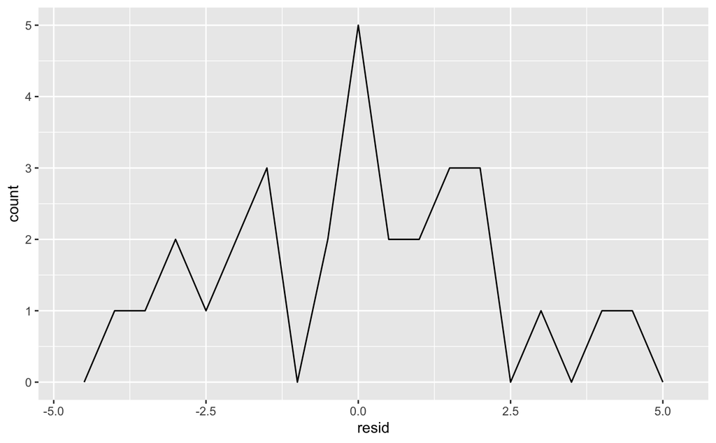

Sometimes you want to create plots using the residuals instead of the original predictor:

```r
ggplot(sim1, aes(x, resid)) +
  geom_ref_line(h = 0) +
  geom_point()
```

## Exercises

1. Instead of using [`lm()`](https://rdrr.io/r/stats/lm.html) to fit a straight line, you can use [`loess()`](https://rdrr.io/r/stats/loess.html) to fit a smooth curve. Repeat the process of model fitting, grid generation, predictions, and visualization on `sim1` using [`loess()`](https://rdrr.io/r/stats/loess.html) instead of [`lm()`](https://rdrr.io/r/stats/lm.html). How does the result compare to [`geom_smooth()`](https://ggplot2.tidyverse.org/reference/geom_smooth.html)?

````
```r
fit3 <- loess(y ~ x, data = sim1)


sim1 <- sim1 %>%
  add_predictions(fit3)
sim1

ggplot(data = sim1, aes(x, y)) +
  geom_point() +
  geom_line(aes(y = pred), color = "skyblue") +
  geom_smooth()
```
````

2. [`add_predictions()`](https://modelr.tidyverse.org/reference/add_predictions.html) is paired with [`gather_predictions()`](https://modelr.tidyverse.org/reference/add_predictions.html) and [`spread_predictions()`](https://modelr.tidyverse.org/reference/add_predictions.html). How do these three functions differ?

   `spread_predictions()` adds one column for each model. `gather_predictions()` adds two columns `.model` and `.pred` and repeats the input rows for each model.
3. What does [`geom_ref_line()`](https://modelr.tidyverse.org/reference/geom_ref_line.html) do? What package does it come from? Why is displaying a reference line in plots showing residuals useful and important?

````
```r
ggplot(data = sim1, aes(x, y)) +
  geom_point() +
  geom_line(aes(y = pred), color = "skyblue") +
  geom_smooth() +
  geom_ref_line(10)
```
````

4. Why might you want to look at a frequency polygon of absolute residuals? What are the pros and cons compared to looking at the raw residuals?

# Formulas and model families

## Categorical variables

```r
ggplot(sim2) +
  geom_point(aes(x, y))
```

We can fit a model to this data and generate predictions:

```r
mod2 <- lm(y ~ x, data = sim2)

grid <- sim2 %>%
  data_grid(x) %>%
  add_predictions(mod2)
grid
```

And visualize:

```r
ggplot(sim2, aes(x)) +
  geom_point(aes(y = y)) +
  geom_point(data = grid, aes(y = pred), colour = "red", size = 4)
```

## Interactions (continuous and categorical)

```r
mod1 <- lm(y ~ x1 + x2, data = sim3)
mod2 <- lm(y ~ x1 * x2, data = sim3)

grid <- sim3 %>%
  data_grid(x1, x2) %>%
  gather_predictions(mod1, mod2)
grid
```

And visualize:

```r
ggplot(sim3, aes(x1, y, colour = x2)) +
  geom_point() +
  geom_line(data = grid, aes(y = pred)) +
  facet_wrap(~ model)
```

To see which model is better for the data, we can visualize the residuals.

```r
sim3 <- sim3 %>%
  gather_residuals(mod1, mod2)

ggplot(sim3, aes(x1, resid, colour = x2)) +
  geom_point() +
  facet_grid(model ~ x2)
```

## Interactions (two continuous)

```r
mod1 <- lm(y ~ x1 + x2, data = sim4)
mod2 <- lm(y ~ x1 * x2, data = sim4)

grid <- sim4 %>%
  data_grid(
    x1 = seq_range(x1, 5),
    x2 = seq_range(x2, 5)
  ) %>%
  gather_predictions(mod1, mod2)
grid
```

```r
ggplot(grid, aes(x1, pred, colour = x2, group = x2)) +
  geom_line() +
  facet_wrap(~ model)
ggplot(grid, aes(x2, pred, colour = x1, group = x1)) +
  geom_line() +
  facet_wrap(~ model)
```

```r
library(splines)
sim5 <- tibble(
  x = seq(0, 3.5 * pi, length = 50),
  y = 4 * sin(x) + rnorm(length(x))
)

ggplot(sim5, aes(x, y)) +
  geom_point()

mod1 <- lm(y ~ ns(x, 1), data = sim5)
mod2 <- lm(y ~ ns(x, 2), data = sim5)
mod3 <- lm(y ~ ns(x, 3), data = sim5)
mod4 <- lm(y ~ ns(x, 4), data = sim5)
mod5 <- lm(y ~ ns(x, 5), data = sim5)

# or
models <- vector("list", length = 5)
for (i in 1:5) {
  models[[i]] <- lm(y ~ ns(x, i), data = sim5)
}

grid <- sim5 %>%
  data_grid(x = seq_range(x, n = 50, expand = 0.1)) %>%
  gather_predictions(mod1, mod2, mod3, mod4, mod5, .pred = "y")

ggplot(sim5, aes(x, y)) +
  geom_point() +
  geom_line(data = grid, colour = "red") +
  facet_wrap(~ model)
```

## Exercises

1. What happens if you repeat the analysis of `sim2` using a model without an intercept. What happens to the model equation? What happens to the predictions?

```r
mod2b <- lm(y ~ -1 + x, data = sim2)
summary(mod2b)

grid <- sim2 %>%
  data_grid(x) %>%
  add_predictions(mod2b)
grid

ggplot(sim2, aes(x)) +
  geom_point(aes(y = y)) +
  geom_point(data = grid, aes(y = pred), colour = "red", size = 4)
```

1. Use `model_matrix()` to explore the equations generated for the models I fit to `sim3` and `sim4`. Why is `*`a good shorthand for interaction?
2. Using the basic principles, convert the formulas in the following two models into functions. (Hint: start by converting the categorical variable into 0-1 variables.)

````
```r
mod1 <- lm(y ~ x1 + x2, data = sim3)
mod2 <- lm(y ~ x1 * x2, data = sim3)

model_function <- function(data, int = TRUE) {
  if (int == TRUE) {
   fit <- lm(y ~ x1 * x2, data = data)
  } else {
   fit <- lm(y ~ x1 + x2, data = data)
  }
  summary(fit)
}

model_function(data = sim3, int = FALSE)
```
````

4. For `sim4`, which of `mod1` and `mod2` is better? I think `mod2` does a slightly better job at removing patterns, but it’s pretty subtle. Can you come up with a plot to support my claim?